# Querying the Data

Jake Conway and Nils Gehlenborg

For all examples the movies data set contained in the package will be used.

```r
library(UpSetR)
movies <- read.csv(system.file("extdata", "movies.csv", package = "UpSetR"),
    header = T, sep = ";")
```

## *queries* Parameter Breakdown

Each list contained in the `queries` parameter takes 4 fields: `query`, `params`, `color`, and `active`.

- `query` specifies which query is going to be run
- `params` is a list of paramters for the query to work on
- `color` is the color that will represent the query on the plot. If no color is provided, a color will be selected from the *UpSetR* default color palette.
- `active` determines how the query will be represented on the plot. If `active` is `TRUE`, the intersection size bar will be overlayed by a bar representing the query. If `active` is `FALSE`, a jitter point will be placed on the intersection size bar.

To learn how queries can be explored and visualized on an element level see the **Attribute Plots** vignette.

## Example 1: Built-in Intersection Query

This example shows how to use the built in intersection query, `intersects`, to find or display elements in specific intersections. In this example the color selected for the active query is from the default color palette.

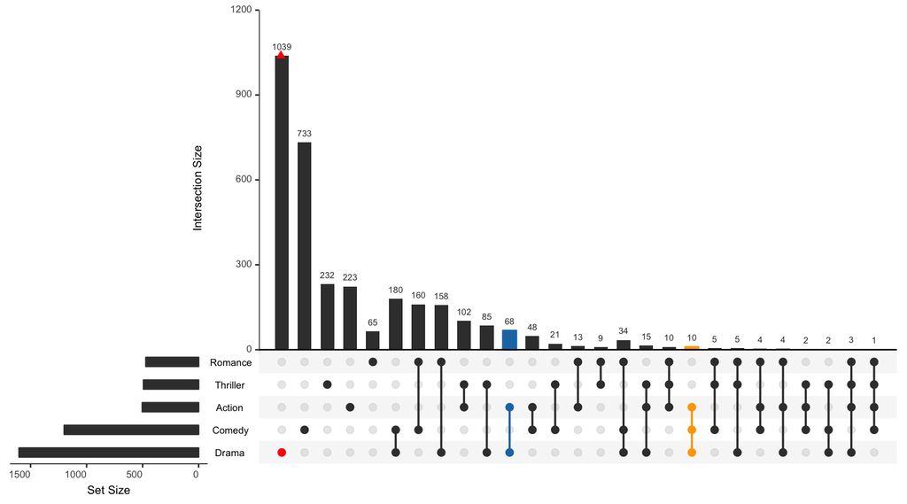

```r
upset(movies, queries = list(list(query = intersects, params = list("Drama",
    "Comedy", "Action"), color = "orange", active = T), list(query = intersects,
    params = list("Drama"), color = "red", active = F), list(query = intersects,
    params = list("Action", "Drama"), active = T)))
```

## Example 2: Built-In Elements Query

This example shows how to use the built in element query, `elements`, to visualize how certain elements are distributed amongst the intersections.

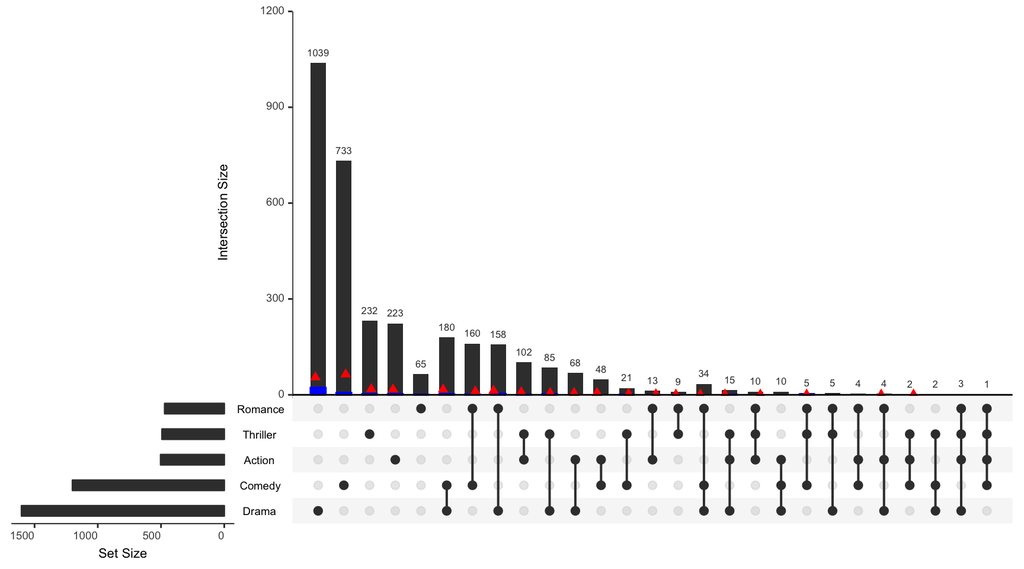

```r
upset(movies, queries = list(list(query = elements, params = list("AvgRating",
    3.5, 4.1), color = "blue", active = T), list(query = elements, params = list("ReleaseDate",
    1980, 1990, 2000), color = "red", active = F)))
```

## Example 3: Using Expression Parameter to Subset Intersection and Element Queries

This example shows how to use the `expression` parameter to subset the results of element and intersection queries.

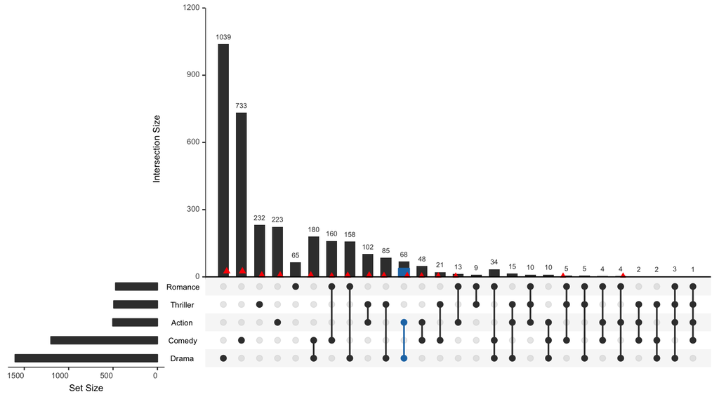

```r
upset(movies, queries = list(list(query = intersects, params = list("Action",
    "Drama"), active = T), list(query = elements, params = list("ReleaseDate",
    1980, 1990, 2000), color = "red", active = F)), expression = "AvgRating > 3 & Watches > 100")
```

## Example 4: Creating Custom Queries on Set Elements and Attributes

Creating a custom query to operate on the rows of the data.

```r
Myfunc <- function(row, release, rating) {
    data <- (row["ReleaseDate"] %in% release) & (row["AvgRating"] > rating)
}
```

Applying the created query to the queries parameter.

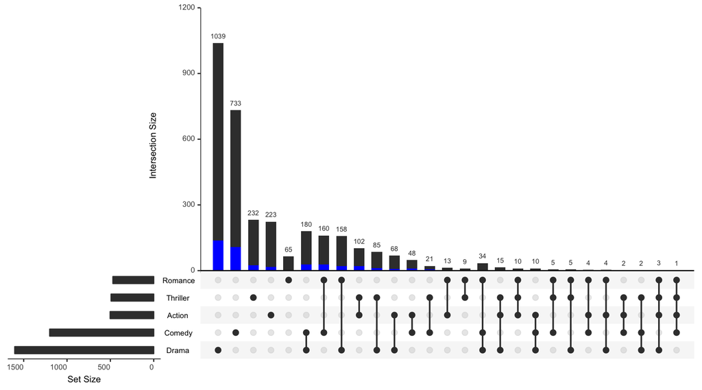

```r
upset(movies, queries = list(list(query = Myfunc, params = list(c(1970, 1980,
    1990, 1999, 2000), 2.5), color = "blue", active = T)))
```

## Example 5: Applying a query legend

To add a legend for the queries applied, the `query.legend` parameter can be used. The `query.legend` parameter takes the position where the legend should be displayed, either *top* or *bottom*. To apply a specific name to each query, the parameter `query.name` can be used when defining the query in the `queries` paramter. If no `query.name` is provided, a generic name will be used. The example below shows how to do this.

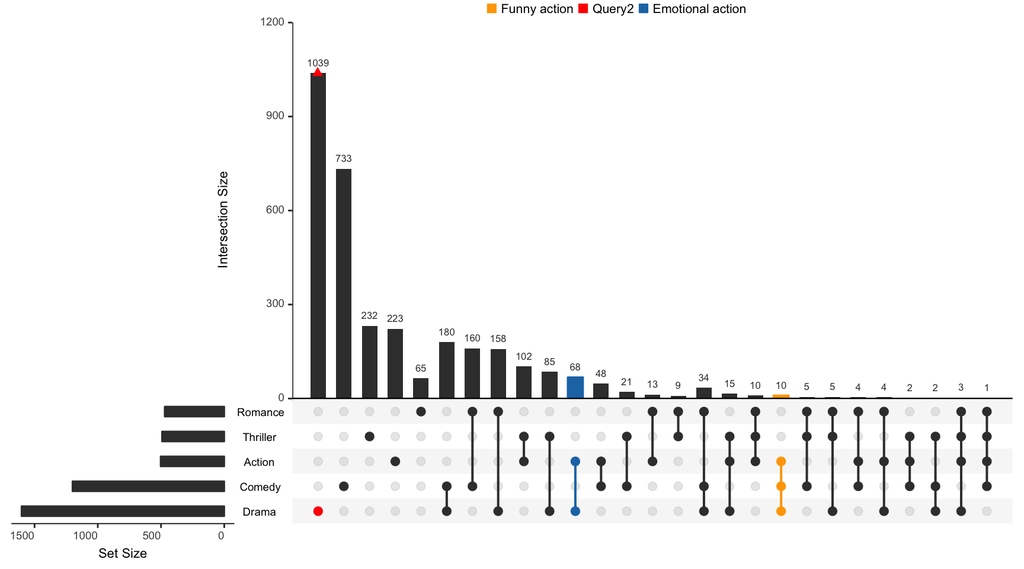

```r
upset(movies, query.legend = "top", queries = list(list(query = intersects,
    params = list("Drama", "Comedy", "Action"), color = "orange", active = T,
    query.name = "Funny action"), list(query = intersects, params = list("Drama"),
    color = "red", active = F), list(query = intersects, params = list("Action",
    "Drama"), active = T, query.name = "Emotional action")))
```

## Example 6: Applying Everything at Once

Combining pieces from all previous examples into one awesome query!

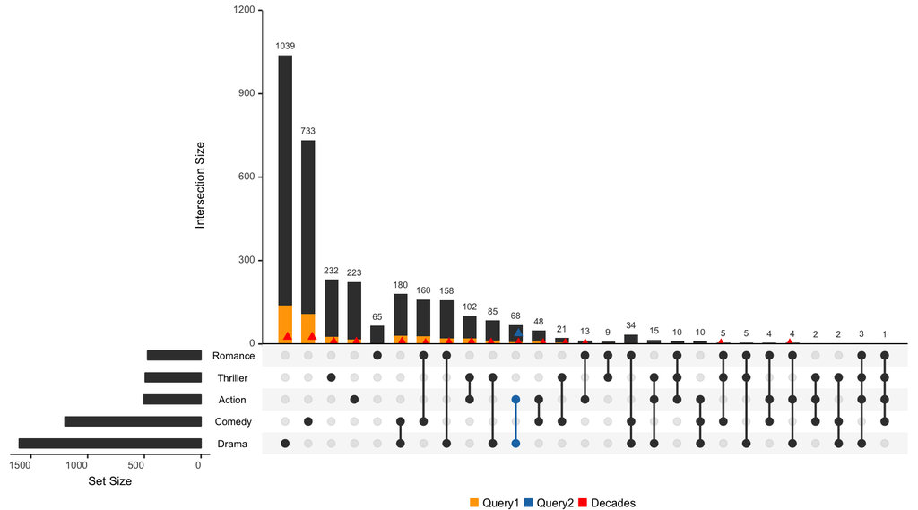

```r
upset(movies, query.legend = "bottom", queries = list(list(query = Myfunc, params = list(c(1970,
    1980, 1990, 1999, 2000), 2.5), color = "orange", active = T), list(query = intersects,
    params = list("Action", "Drama"), active = F), list(query = elements, params = list("ReleaseDate",
    1980, 1990, 2000), color = "red", active = F, query.name = "Decades")),
    expression = "AvgRating > 3 & Watches > 100")
```